# Risk Factor Analysis

## Outcome Variable

**Outcome Variable:** haz

## Predictor Variables

**Intervention Variable:** hfoodsec

**Adjustment Set:**

- arm
- sex
- W_mage
- meducyrs
- feducyrs
- hhwealth_quart
- vagbrth
- W_nrooms
- W_nchldlt5
- brthmon
- W_parity
- impfloor
- impsan
- safeh20
- delta_W_mage
- delta_meducyrs
- delta_feducyrs
- delta_hhwealth_quart
- delta_vagbrth
- delta_W_nrooms
- delta_W_nchldlt5
- delta_brthmon
- delta_W_parity
- delta_impfloor
- delta_impsan
- delta_safeh20

## Stratifying Variables

The analysis was stratified on these variable(s):

- agecat

## Data Summary

| agecat | hfoodsec | n_cell | n |
| --- | --- | --- | --- |
| Birth | Food Secure | 6931 | 14342 |
| Birth | Mildly Food Insecure | 4742 | 14342 |
| Birth | Food Insecure | 2669 | 14342 |
| 6 months | Food Secure | 12362 | 24382 |
| 6 months | Mildly Food Insecure | 8109 | 24382 |
| 6 months | Food Insecure | 3911 | 24382 |
| 24 months | Food Secure | 7628 | 15356 |
| 24 months | Mildly Food Insecure | 5067 | 15356 |
| 24 months | Food Insecure | 2661 | 15356 |

The following strata were considered:

- agecat: 24 months
- agecat: 6 months
- agecat: Birth

## Methods Detail

We’re interested in the causal parameters $E[Y_a]$ for all values of $a \in \mathcal{A}$. These parameters represent the mean outcome if, possibly contrary to fact, we intervened to set all units to have $A=a$. Under the randomization and positivity assumptions, these are identified by the statistical parameters $\psi_a=E_W[E_{Y|A,W}(Y|A=a,W)]$. In addition, we’re interested in the mean of $Y$, $E[Y]$ under no intervention (the observed mean). We will estimate these parameters by using SuperLearner to fit the relevant likelihood factors – $E_{Y|A,W}(Y|A=a,W)$ and $p(A=a|W)$, and then updating our likelihood fit using a joint TMLE.

For unadjusted analyses ($W=\{\}$), initial likelihoods were estimated using Lrnr_glm to estimate the simple $E(Y|A)$ and Lrnr_mean to estimate $p(A)$. For adjusted analyses, a small library containing Lrnr_glmnet, Lrnr_xgboost, and Lrnr_mean was used.

Having estimated these parameters, we will then use the delta method to estimate relative risks and attributable risks relative to a prespecified baseline level of $A$.

# Results Detail

## Results Plots

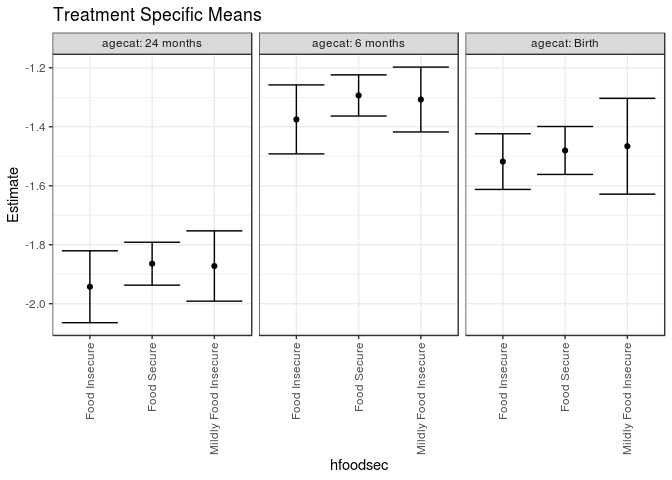

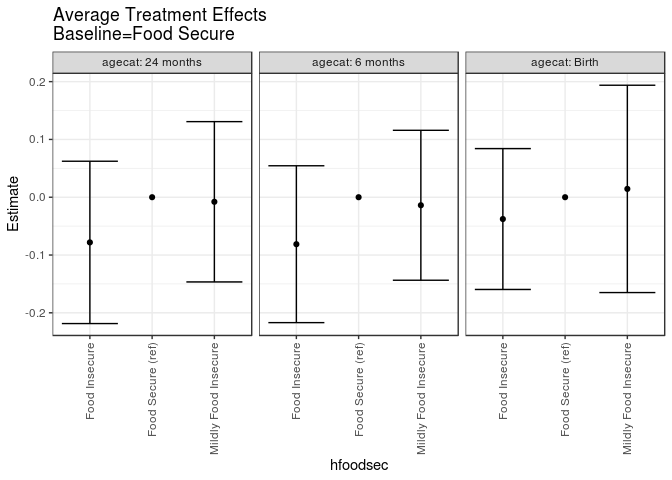

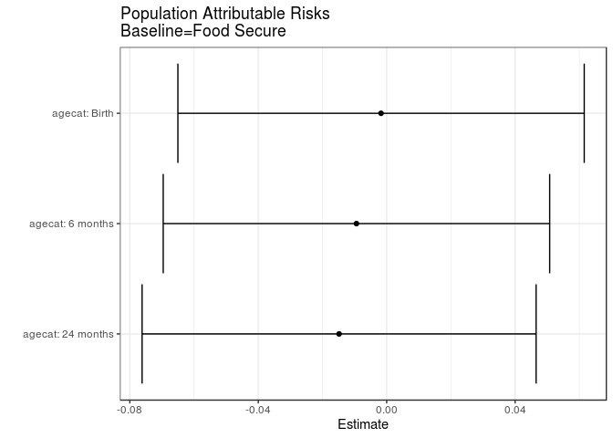

## Results Table

### Parameter: TSM

| agecat | intervention_level | baseline_level | estimate | ci_lower | ci_upper |
| --- | --- | --- | --- | --- | --- |
| Birth | Food Secure | NA | -1.480333 | -1.561621 | -1.399045 |
| Birth | Mildly Food Insecure | NA | -1.465942 | -1.628372 | -1.303512 |
| Birth | Food Insecure | NA | -1.518071 | -1.612467 | -1.423674 |
| 6 months | Food Secure | NA | -1.293699 | -1.363479 | -1.223920 |
| 6 months | Mildly Food Insecure | NA | -1.307600 | -1.417657 | -1.197544 |
| 6 months | Food Insecure | NA | -1.374991 | -1.491987 | -1.257994 |
| 24 months | Food Secure | NA | -1.864276 | -1.937042 | -1.791510 |
| 24 months | Mildly Food Insecure | NA | -1.872186 | -1.991413 | -1.752959 |
| 24 months | Food Insecure | NA | -1.942425 | -2.064331 | -1.820518 |

### Parameter: E(Y)

| agecat | intervention_level | baseline_level | estimate | ci_lower | ci_upper |
| --- | --- | --- | --- | --- | --- |
| Birth | NA | NA | -1.482085 | -1.527667 | -1.436504 |
| 6 months | NA | NA | -1.303117 | -1.337567 | -1.268666 |
| 24 months | NA | NA | -1.879098 | -1.916956 | -1.841240 |

### Parameter: ATE

| agecat | intervention_level | baseline_level | estimate | ci_lower | ci_upper |
| --- | --- | --- | --- | --- | --- |
| Birth | Food Secure | Food Secure | 0.0000000 | 0.0000000 | 0.0000000 |
| Birth | Mildly Food Insecure | Food Secure | 0.0143911 | -0.1649896 | 0.1937717 |
| Birth | Food Insecure | Food Secure | -0.0377379 | -0.1596130 | 0.0841373 |
| 6 months | Food Secure | Food Secure | 0.0000000 | 0.0000000 | 0.0000000 |
| 6 months | Mildly Food Insecure | Food Secure | -0.0139011 | -0.1436024 | 0.1158002 |
| 6 months | Food Insecure | Food Secure | -0.0812911 | -0.2169906 | 0.0544084 |
| 24 months | Food Secure | Food Secure | 0.0000000 | 0.0000000 | 0.0000000 |
| 24 months | Mildly Food Insecure | Food Secure | -0.0079102 | -0.1465927 | 0.1307723 |
| 24 months | Food Insecure | Food Secure | -0.0781493 | -0.2185907 | 0.0622922 |

### Parameter: PAR

| agecat | intervention_level | baseline_level | estimate | ci_lower | ci_upper |
| --- | --- | --- | --- | --- | --- |
| Birth | Food Secure | NA | -0.0017525 | -0.0650303 | 0.0615253 |
| 6 months | Food Secure | NA | -0.0094174 | -0.0696006 | 0.0507658 |
| 24 months | Food Secure | NA | -0.0148223 | -0.0761795 | 0.0465349 |